# Transition of Multiple Sclerosis Patients from Relapsing-Remitting to Secondary Progressive Disease

## 10.1 Modified Kitchen Sink Model

I will begin by using a restricted cubic spline with four knots on the ONSET_AGE predictor. The output for the resulting model (in which ONLY age of onset has been transformed) can be seen below. The model has an R-squared value of approximately 30%, with an adjusted R-squared value of approximately 23%.

```r
dd <- datadist(acpdata.imputed.SP)
options(datadist = "dd")

model1.lm <- ols(TIME_TO_SP ~ rcs(ONSET_AGE, 4) + TIME_TO_2ND_EXC + MALE + NUMBER_IMPAIRED_DOMAINS_CAT + AD_AT_ONSET,
                 data = acpdata.imputed.SP, x = TRUE, y = TRUE)

model1.lm
```

```
Linear Regression Model

 ols(formula = TIME_TO_SP ~ rcs(ONSET_AGE, 4) + TIME_TO_2ND_EXC +
     MALE + NUMBER_IMPAIRED_DOMAINS_CAT + AD_AT_ONSET, data = acpdata.imputed.SP,
     x = TRUE, y = TRUE)

                Model Likelihood     Discrimination
                   Ratio Test           Indexes
 Obs     121    LR chi2     43.35    R2       0.301
 sigma4.6556    d.f.           11    R2 adj   0.231
 d.f.    109    Pr(> chi2) 0.0000    g        3.351

 Residuals

      Min       1Q   Median       3Q      Max
 -11.1327  -2.8229  -0.3044   3.1698  12.1111


                                   Coef    S.E.   t     Pr(>|t|)
 Intercept                          7.4668 6.1213  1.22 0.2252
 ONSET_AGE                          0.1723 0.2255  0.76 0.4467
 ONSET_AGE'                        -1.6074 0.9785 -1.64 0.1033
 ONSET_AGE''                        4.0061 2.5073  1.60 0.1130
 TIME_TO_2ND_EXC                    0.3750 0.1160  3.23 0.0016
 MALE                              -1.4717 0.9997 -1.47 0.1439
 NUMBER_IMPAIRED_DOMAINS_CAT=1 - 2 -0.1131 1.6930 -0.07 0.9468
 NUMBER_IMPAIRED_DOMAINS_CAT=3 - 4  2.2672 1.9361  1.17 0.2441
 NUMBER_IMPAIRED_DOMAINS_CAT=5 - 6 -1.0687 2.1989 -0.49 0.6279
 NUMBER_IMPAIRED_DOMAINS_CAT=7 - 8 -2.8551 2.8927 -0.99 0.3258
 NUMBER_IMPAIRED_DOMAINS_CAT=9 +   -0.2700 2.8191 -0.10 0.9239
 AD_AT_ONSET                        0.9157 0.9419  0.97 0.3331
```

### 10.1.1 ANOVA Analysis of Model 1

```r
anova(model1.lm)
```

```
                Analysis of Variance          Response: TIME_TO_SP

 Factor                      d.f. Partial SS MS        F     P
 ONSET_AGE                     3   451.64329 150.54776  6.95 0.0003
  Nonlinear                    2    59.46664  29.73332  1.37 0.2580
 TIME_TO_2ND_EXC               1   226.47706 226.47706 10.45 0.0016
 MALE                          1    46.97598  46.97598  2.17 0.1439
 NUMBER_IMPAIRED_DOMAINS_CAT   5   143.56433  28.71287  1.32 0.2590
 AD_AT_ONSET                   1    20.48332  20.48332  0.95 0.3331
 REGRESSION                   11  1017.93009  92.53910  4.27 <.0001
 ERROR                       109  2362.51619  21.67446
```

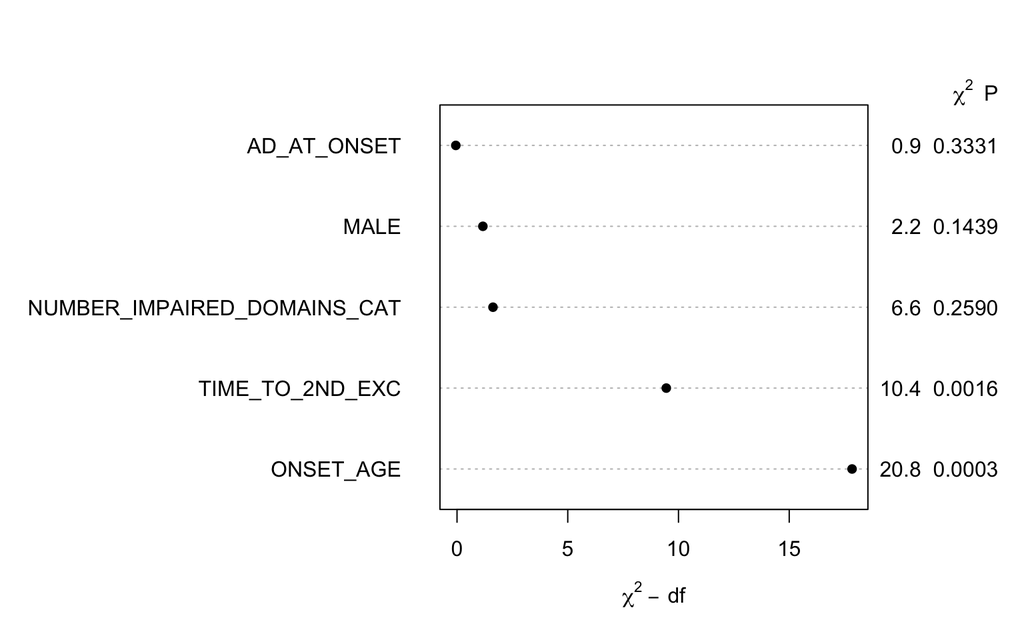

```r
plot(anova(model1.lm))
```

### 10.1.2 Effects Plot

An effects plot confirms the results of the ANOVA analysis above. ONSET-AGE and TIME_TO_2ND_EXC easily clear the null value of 0, while MALE comes very close, but does not quite clear the null value of the confidence interval.

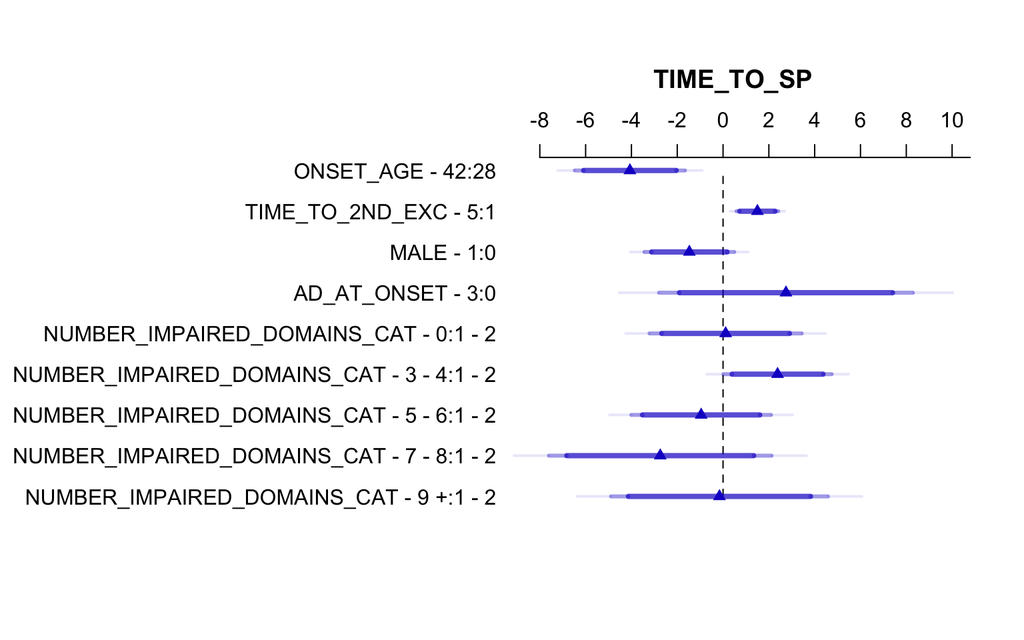

```r
plot(summary(model1.lm))
```

### 10.1.3 Nomogram

Interestingly, in the nomogram of the linear model, the NUMBER_IMPAIRED_DOMAINS_CAT variable does not proceed in numeric order of categories (i.e., 0 comes first, then 1 - 2, then 3 - 4, etc).

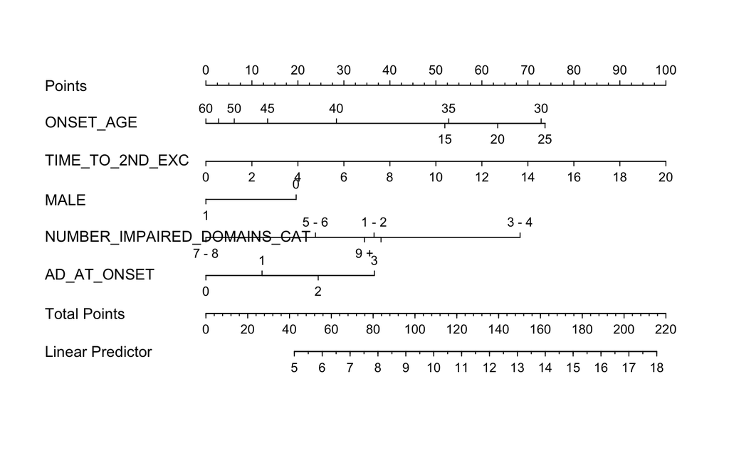

```r
plot(nomogram(model1.lm))
```

Elina Misicka

2018-03-08 10:25:35